# Training an acoustic model on Mandarin data

We will train an acoustic model of Mandarin using a large dataset (~10h) in this notebook. The data can be found in the Google Drive as THCHS30_part.zip. The zip files consists of folders for multiple speakers and that include wav and lab files. The dataset is a part of the THCHS30 corpus, the full corpus can be found [here](https://openslr.org/18/).

```python
! mfa model download dictionary mandarin_china_mfa
```

The dataset from the Google Drive folder contains only the utterance where all words can be found in the downlaoded dictionary. However, we check first if there is an error in the corpus by using the validate command:

```python
! mfa validate --clean ~/Workspace/corpora/thchs30_part/ mandarin_china_mfa
```

```
INFO - Setting up corpus information...
INFO - Loading corpus from source files...
4069it [00:02, 1940.99it/s]
INFO - Found 60 speakers across 4069 files, average number of utterances per
                speaker: 67.81666666666666
INFO - Initializing multiprocessing jobs...
INFO - Normalizing text...
INFO - Creating corpus split for feature generation...
INFO - Generating MFCCs...
4080it [00:48, 84.68it/s]
INFO - Calculating CMVN...
INFO - Generating final features...
INFO - Creating corpus split with features...

INFO - ******
INFO - Corpus
INFO - ******

INFO -   4069 sound files
INFO -   4069 text files
INFO -   60 speakers
INFO -   4069 utterances
INFO -   37395.346 seconds total duration

INFO -   Sound file read errors
INFO -   ======================

INFO -     There were no issues reading sound files.

INFO -   Feature generation
INFO -   ==================

INFO -     There were no utterances missing features.

INFO -   Files without transcriptions
INFO -   ============================

INFO -     There were no sound files missing transcriptions.

INFO -   Transcriptions without sound files
```

[output cut: 72 more lines]

[output not shown]

```python
! mfa train --clean ~/Workspace/corpora/thchs30_part/ mandarin_china_mfa ~/Workspace/thchs30_model.zip
```

```
WARNING - The previous run had a different configuration than the current, which
                   may cause issues. Please see the log for details or use
                   --clean flag if issues are encountered.
INFO - Setting up corpus information...
INFO - Loading corpus from source files...
4069it [00:02, 1975.60it/s]
INFO - Found 60 speakers across 4069 files, average number of utterances per
                speaker: 67.81666666666666
INFO - Initializing multiprocessing jobs...
INFO - Normalizing text...
INFO - Creating corpus split for feature generation...
INFO - Generating MFCCs...
4080it [00:46, 87.00it/s]
INFO - Calculating CMVN...
INFO - Generating final features...
INFO - Creating corpus split with features...
INFO - Initializing training for monophone...
INFO - Compiling training graphs...
INFO - Generating initial alignments...
INFO - Initialization complete!
INFO - monophone - Iteration 1 of 40
INFO - Generating alignments...
INFO - Accumulating statistics...
INFO - monophone - Iteration 2 of 40
INFO - Generating alignments...
INFO - Accumulating statistics...
INFO - monophone - Iteration 3 of 40
INFO - Generating alignments...
INFO - Accumulating statistics...
INFO - monophone - Iteration 4 of 40
INFO - Generating alignments...
INFO - Accumulating statistics...
INFO - monophone - Iteration 5 of 40
INFO - Generating alignments...
INFO - Accumulating statistics...
INFO - monophone - Iteration 6 of 40
INFO - Generating alignments...
INFO - Accumulating statistics...
INFO - monophone - Iteration 7 of 40
INFO - Generating alignments...
```

[output cut: 528 more lines]

```
INFO - Training complete!
INFO - Exiting training early to save time as the corpus is below the subset
                size for later training stages
INFO - Compiling training graphs...
INFO - Generating alignments...
INFO - Calculating fMLLR for speaker adaptation...
INFO - Generating alignments...
INFO - Accumulating transition stats...
INFO - Finished accumulating transition stats!
INFO - Beginning phone LM training...
INFO - Collecting training data...
INFO - Training model...
INFO - Completed training in 2310.6078288555145 seconds!
INFO - Saved model to /home/philipp/Workspace/thchs30_model.zip
INFO - Done! Everything took 2416.310 seconds
```

Since the training of the acoustic model is complete, we can align the data:

```python
! mfa align --clean ~/Workspace/corpora/thchs30_part/ mandarin_china_mfa ~/Workspace/thchs30_model.zip ~/Workspace/corpora/thchs_alignments/
```

```
INFO - Setting up corpus information...
INFO - Loading corpus from source files...
4069it [00:02, 1858.79it/s]
INFO - Found 60 speakers across 4069 files, average number of utterances per
                speaker: 67.81666666666666
INFO - Initializing multiprocessing jobs...
INFO - Normalizing text...
INFO - Creating corpus split for feature generation...
INFO - Generating MFCCs...
4080it [00:47, 86.78it/s]
INFO - Calculating CMVN...
INFO - Generating final features...
INFO - Creating corpus split with features...
INFO - Compiling training graphs...
INFO - Performing first-pass alignment...
INFO - Generating alignments...
INFO - Calculating fMLLR for speaker adaptation...
INFO - Performing second-pass alignment...
INFO - Generating alignments...
INFO - Exporting alignment TextGrids to
                /home/philipp/Workspace/corpora/thchs_alignments...
INFO - Finished exporting TextGrids to
                /home/philipp/Workspace/corpora/thchs_alignments!
INFO - Done! Everything took 178.709 seconds
```

The mfa provides also an acoustic model of Mandarin. We can compare the alignments of our model with the ones generated from the pre-trained model. Note that the pre-trained model had a lot more training data than our model. Download it using the following command:

```python
! mfa model download acoustic mandarin_mfa
```

```
INFO - Saved model to
                /home/philipp/Documents/MFA/pretrained_models/acoustic/mandarin_
                mfa.zip, you can now use mandarin_mfa in place of acoustic paths
                in mfa commands.
```

We align now the dataset using the pre-trained model:

```python
! mfa align --clean ~/Workspace/corpora/thchs30_part/ mandarin_china_mfa mandarin_mfa ~/Workspace/corpora/thchs_mfa_alignments/
```

```
INFO - Setting up corpus information...
INFO - Loading corpus from source files...
4069it [00:02, 1864.29it/s]
INFO - Found 60 speakers across 4069 files, average number of utterances per
                speaker: 67.81666666666666
INFO - Initializing multiprocessing jobs...
INFO - Normalizing text...
INFO - Creating corpus split for feature generation...
INFO - Generating MFCCs...
4080it [01:02, 65.39it/s]
INFO - Calculating CMVN...
INFO - Generating final features...
INFO - Creating corpus split with features...
INFO - Compiling training graphs...
INFO - Performing first-pass alignment...
INFO - Generating alignments...
INFO - Calculating fMLLR for speaker adaptation...
INFO - Performing second-pass alignment...
INFO - Generating alignments...
INFO - Exporting alignment TextGrids to
                /home/philipp/Workspace/corpora/thchs_mfa_alignments...
INFO - Finished exporting TextGrids to
                /home/philipp/Workspace/corpora/thchs_mfa_alignments!
INFO - Done! Everything took 232.942 seconds
```

We can compare now the alignments of our acoustic model with the ones from the pre-trained MFA model. Word-alignments are good overall and the phone aligments are comparable.

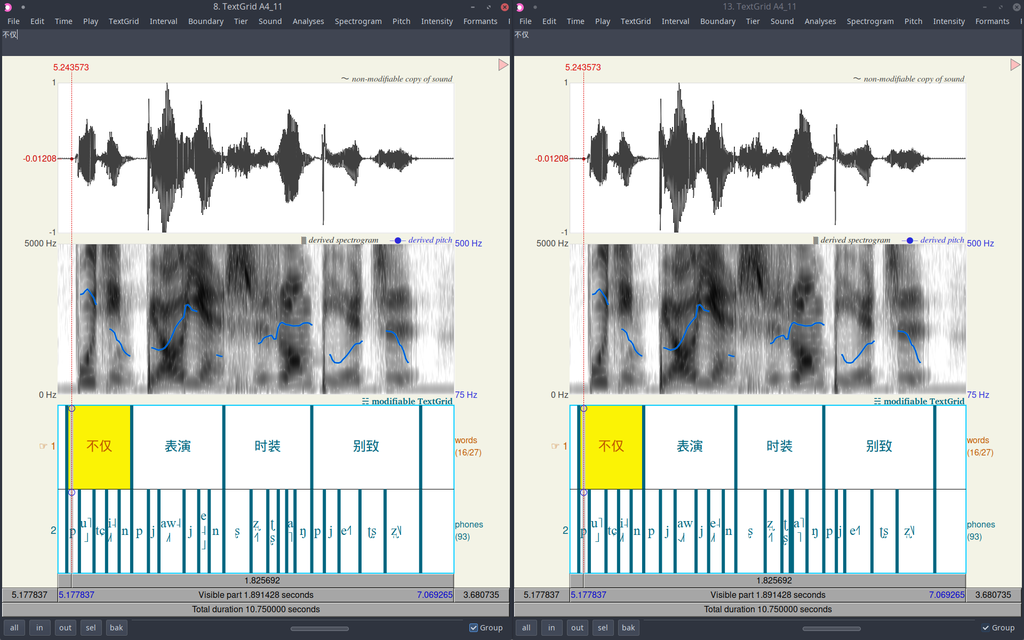